# Data Scientist Jobs in San Francisco Bay Area

Kevin Yu

9/24/2019

## Abstract

Data Scientist is currently one of the most sought after positions by employers, and San Francisco Bay Area, the center of technology companies big and small, is the place that offers the largest amount of such positions with some of the highest pays. As a student of business Analytics, with Data Scientist as one of my potential career paths, it is of my greatest interest to investigate the job market in the Bay Area for Data Scientists.

In this assignment, I scraped the data on `indeed.com` with the `rvest` package, searching for job positions matching “data scientist” and within 25 miles of San Francisco Bay Area. I also used regular expressions to detect common data skills, such as R and Python, from job descriptions, to see which skills are the most sought after. I then used `ggplot2` for visual analyses and `tm` and `wordcloud` to build a wordcloud of the job descriptions.

In the analysis part, I found that

- San Francisco is the most prominent city that offers the most Data Scientist jobs around the Bay Area (suprise)
- The most common salaries for Data Scientist positions are around 100k to 200k in the Bay Area
- The most frequently required skill is Python
- The wordcloud of the job descriptions are full of generic words such as “data” and “experience”, but curiously, “machine” and “learning” are notably prominent

## Web Scraping

I first searched `indeed.com` for “data scientist” jobs within 25 miles of “San Francisco Bay Area, CA”, with 50 jobs per page. There were a total of 20 pages. I proceeded to generate the 20 urls:

```r
# url of indeed.com
indeed <- "https://www.indeed.com"

# base url of the search result
search_result_base <- "https://www.indeed.com/jobs?q=data+scientist&l=San+Francisco+Bay+Area%2C+CA&limit=50&radius=25"

# generate 20 page numbers
page_num <- seq(0, 950, by = 50)

# paste each link together
search_result <- paste0(search_result_base, "&start=", page_num)
```

Then I used the SelectorGadget on Chrome to find the html nodes of the links to each job, and scraped the web to get a total of 1081 jobs.

```r
# loop over 20 pages for partial url to the jobs
url_list <- list()
for (i in seq_along(search_result)) {
  url_list[[i]] <- read_html(search_result[i]) %>%
    html_nodes("#resultsCol .jobtitle") %>%
    html_attr("href")
}

# put all partial urls into one vector
partial_url <- c(url_list[[1]], url_list[[2]],
                 url_list[[3]], url_list[[4]],
                 url_list[[5]], url_list[[6]],
                 url_list[[7]], url_list[[8]],
                 url_list[[9]], url_list[[10]],
                 url_list[[11]], url_list[[12]],
                 url_list[[12]], url_list[[14]],
                 url_list[[15]], url_list[[16]],
                 url_list[[17]], url_list[[18]],
                 url_list[[19]], url_list[[20]])

# paste partial url to indeed.com
full_url <- paste0(indeed, partial_url)
```

I wrote a `get_job` function that, within each job page, scrapes the job title, company name, location, salary information, and job description:

```r
get_job <- function(url) {

  # read job page
  job <- read_html(url)

  # get job title
  title <- job %>%
    html_nodes(".jobsearch-JobInfoHeader-title") %>%
    html_text()

  # info is a vector that contains 3 strings:
  # company name, "-", and salary information
  info <- job %>%
    html_nodes(".icl-u-xs-mr--xs") %>%
    html_text()

  # store company name
  company <- info[1]

  # store salary information
  salary <- info[3]

  # get location
  location <- job %>%
    html_nodes(".jobsearch-DesktopStickyContainer-companyrating") %>%
    html_text() %>%
    str_extract("(?<=\\-).+")

  # get job description
  description <- job %>%
    html_nodes("#jobDescriptionText") %>%
    html_text()

  # return a tibble
  out <- tibble(
    url = url,
    title = title,
    company = company,
    location = location,
    salary = salary,
    description = description
  )

  return(out)

}
```

And I applied the function to each job page:

```r
# generate empty outcome dataframe
ds <- tibble(
  title = character(0),
  company = character(0),
  location = character(0),
  salary = character(0),
  description = character(0)
)

# loop over all jobs and apply get_job function
for (url in full_url) {

  ds <- ds %>%
    bind_rows(get_job(url))

}

# export to .csv file
write_csv(ds, "ds_san_francisco.csv")
```

After writing the dataframe into a `.csv` file, I changed all the above trunks into `eval = FALSE` to prevent those codes from running again everytime I knit, so that I won’t encounter unexpected internet connection error or the data won’t change because new jobs are posted everyday. From this point forward, I will only work with the data I have already scraped.

## Data Cleansing

For data cleansing, I separated the `location` column into `city`, `state`, and `zipcode`, and I standardized the salary information into `minsalary` and `maxsalary`.

```r
ds <- read_csv("ds_san_francisco.csv")

# drop one observation that doesn't have company name and location
df1 <- ds %>%
  drop_na(location)

# fix unexpected entries in the location column
df2 <- df1
for (i in 1:nrow(df1)) {

  if (str_detect(df2[i,3], "\\-") == TRUE){
    df2[i,3] <- df2[i,3] %>%
      str_extract_all("(?<=\\-).+")
  }

  df2[i,4] <- df2[i,4] %>%
    str_remove(" a year") %>%
    str_remove("From ") %>%
    str_remove(" an hour")

}

# separate location column into city, state, and zipcode
df3 <- df2 %>%

  separate(location,
           into = c("city", "temp"),
           sep = ", ") %>%
  separate(temp,
           into = c("state", "zipcode"),
           sep = " ") %>%
  separate(salary,
           into = c("minsalary", "maxsalary"),
           sep = " \\- ") %>%

  # parse salary as numbers
  mutate(minsalary = parse_number(minsalary)) %>%
  mutate(maxsalary = parse_number(maxsalary)) %>%

  # remove positions that offer hourly wages
  filter(minsalary > 1000 | is.na(minsalary))

df3[,3:7]
```

```
## # A tibble: 1,076 x 5
##    city                state zipcode minsalary maxsalary
##    <chr>               <chr> <chr>       <dbl>     <dbl>
##  1 Benicia             CA    94510          NA        NA
##  2 Pleasanton          CA    94566      110000    135000
##  3 San Francisco       CA    <NA>           NA        NA
##  4 San Francisco       CA    94107      150000    200000
##  5 South San Francisco CA    94080          NA        NA
##  6 Redwood City        CA    <NA>           NA        NA
##  7 San Francisco       CA    <NA>       100000    150000
##  8 San Francisco       CA    <NA>           NA        NA
##  9 San Francisco       CA    <NA>           NA        NA
## 10 San Mateo           CA    94401          NA        NA
## # … with 1,066 more rows
```

```r
# make job descriptions lower-case
df4 <- df3
for(i in 1:nrow(df4)) {

  df4[i,8] <- str_to_lower(df4[i,8])

}
```

I then used regular expressions to detect what skills are mentioned in each job’s description:

```r
df5 <- df4

# generate empty columns
df5$python <- NA
df5$r <- NA
df5$sql <- NA
df5$sas <- NA
df5$c <- NA
df5$java <- NA

# loop over each observatoin
for (i in 1:nrow(df5)) {

  # detect python
  if (str_detect(df5[i,8], "python")) {
    df5[i,10] <- "TRUE"
  } else {
    df5[i,10] <- "FALSE"
  }

  # detect r
  if (str_detect(df5[i,8],
                 paste(c("(?<=[:blank:])r(?![:alpha:])",
                         "(?<![:alpha:])r(?=[:blank:])",
                         "(?<=[:punct:])r(?![:alpha:])",
                         "(?<![:alpha:])r(?=[:punct:])"),
                       collapse = "|"))) {
    df5[i,11] <- "TRUE"
  } else {
    df5[i,11] <- "FALSE"
  }

  # detect sql
  if (str_detect(df5[i,8], "sql")) {
    df5[i,12] <- "TRUE"
  } else {
    df5[i,12] <- "FALSE"
  }

  # detect sas
  if (str_detect(df5[i,8], "sas")) {
    df5[i,13] <- "TRUE"
  } else {
    df5[i,13] <- "FALSE"
  }

  # detect c, including c++, c#, objective c
  if (str_detect(df5[i,8],
                 paste(c("(?<=[:blank:])c(?![:alpha:])",
                         "(?<![:alpha:])c(?=[:blank:])",
                         "(?<=[:punct:])c(?![:alpha:])",
                         "(?<![:alpha:])c(?=[:punct:])",
                         "c\\+\\+", "c\\#", "objective c",
                         "objective\\-c"),
                       collapse = "|"))) {
    df5[i,14] <- "TRUE"
  } else {
    df5[i,14] <- "FALSE"
  }

  # detect java, but not javascript
  if (str_detect(df5[i,8], "java(?![:alpha:])")) {
    df5[i,15] <- "TRUE"
  } else {
    df5[i,15] <- "FALSE"
  }

}

df <- df5

df[10:15]
```

```
## # A tibble: 1,076 x 6
##    python r     sql   sas   c     java
##    <chr>  <chr> <chr> <chr> <chr> <chr>
##  1 TRUE   TRUE  TRUE  FALSE TRUE  FALSE
##  2 TRUE   FALSE FALSE FALSE FALSE FALSE
##  3 TRUE   FALSE FALSE FALSE FALSE TRUE
##  4 TRUE   TRUE  FALSE FALSE FALSE FALSE
##  5 FALSE  TRUE  FALSE TRUE  FALSE FALSE
##  6 TRUE   TRUE  TRUE  FALSE FALSE FALSE
##  7 TRUE   FALSE FALSE FALSE FALSE FALSE
##  8 FALSE  FALSE FALSE FALSE FALSE FALSE
##  9 FALSE  FALSE FALSE FALSE FALSE FALSE
## 10 TRUE   TRUE  FALSE FALSE TRUE  TRUE
## # … with 1,066 more rows
```

## Analysis

### Cities

San Francisco is, undoubtedly, the most prominent city around the Bay Area, but other cities, such as Redwood City and San Mateo, also offer a lot of Data Scientist jobs, if one seeks opportunities around that area.

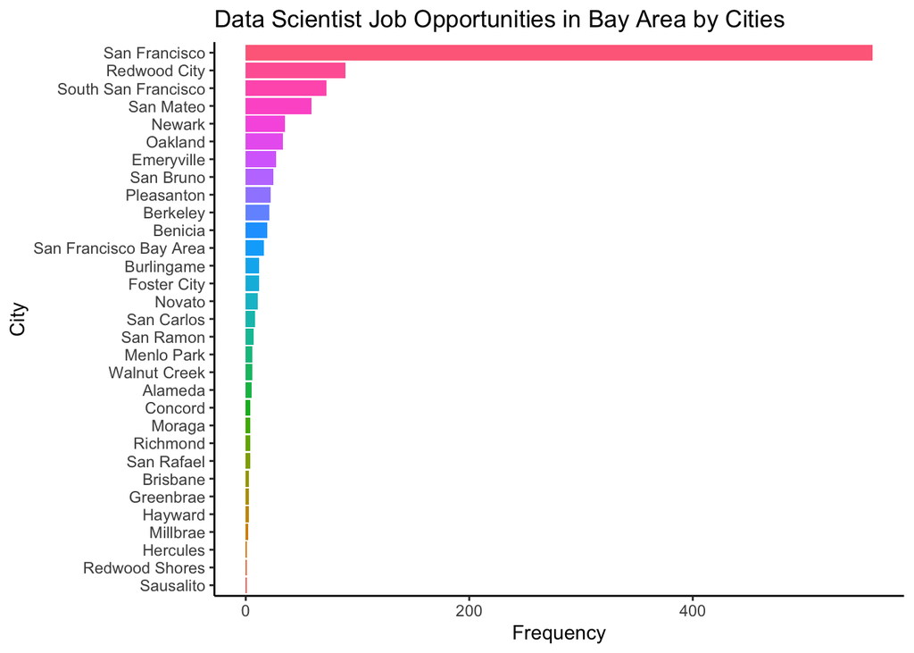

```r
df$city <- fct_rev(fct_infreq(as.factor(df$city)))

ggplot(df, aes(city, fill = city)) +
  geom_bar() +
  labs(title = "Data Scientist Job Opportunities in Bay Area by Cities",
       x = "City",
       y = "Frequency") +
  coord_flip() +
  theme_classic() +
  theme(legend.position = "none")
```

### Salary

Most of the jobs I scraped do not provide salary data. In fact, less than 100 positions out of the 1000+ provide salary information. Out of those, a salary around $100k to $200k is the most common, but some offers as high as over $300k and some are as low as just obove $50k.

```r
summary(df$minsalary)
```

```
##    Min. 1st Qu.  Median    Mean 3rd Qu.    Max.    NA's
##   23000  110000  110000  125673  150000  200000    1027
```

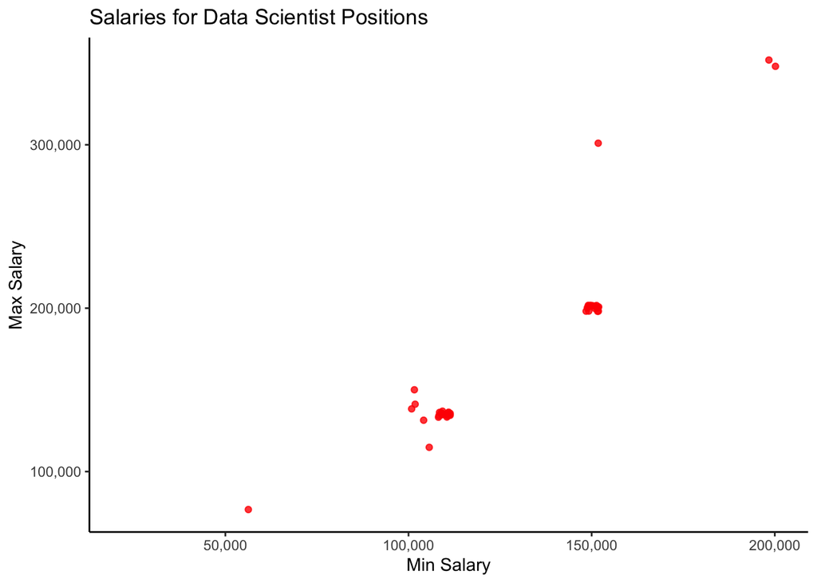

```r
ggplot(df, aes(minsalary, maxsalary)) +
  geom_jitter(color = "red", alpha = 0.8) +
  scale_x_continuous(labels = scales::comma) +
  scale_y_continuous(labels = scales::comma) +
  labs(title = "Salaries for Data Scientist Positions",
       x = "Min Salary",
       y = "Max Salary") +
  theme_classic()
```

### Skills

Out of the 6 skills I decided to detect, Python is the most frequently sought after skill, mentioned by over 66% of the jobs, followed by R and SQL. Other programming languages, such as C and Java, are less frequently required, with a mention rate less than 25%. SAS is the least required among the 6, but by no means obsolete.

```r
python <- table(df$python)
r <- table(df$r)
sql <- table(df$sql)
sas <- table(df$sas)
c <- table(df$c)
java <- table(df$java)

skills <- tibble(
  Skill = c("Python", "R", "SQL",
            "SAS", "C", "Java"),
  Required = c(python[2],
               r[2],
               sql[2],
               sas[2],
               c[2],
               java[2]),
  `Not Required` = c(python[1],
                     r[1],
                     sql[1],
                     sas[1],
                     c[1],
                     java[1])
)

skills
```

```
## # A tibble: 6 x 3
##   Skill  Required `Not Required`
##   <chr>     <int>          <int>
## 1 Python      713            363
## 2 R           427            649
## 3 SQL         424            652
## 4 SAS         133            943
## 5 C           228            848
## 6 Java        220            856
```

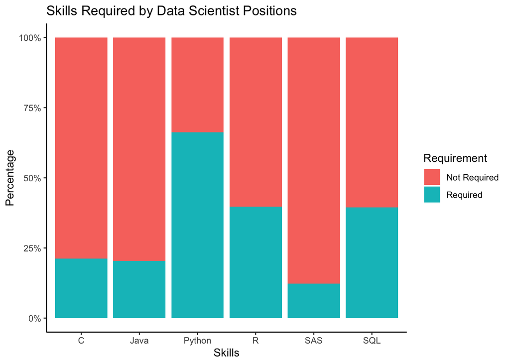

```r
library(reshape2)

melt(skills, measure.vars = c("Required","Not Required"),
     variable.name = "Requirement", value.name = "Value") %>%
  ggplot(aes(Skill, Value, fill = fct_rev(as.factor(Requirement)))) +
  geom_bar(stat = "identity", position = "fill") +
  labs(title = "Skills Required by Data Scientist Positions",
       x = "Skills",
       y = "Percentage",
       fill = "Requirement") +
  scale_y_continuous(labels = scales::percent) +
  theme_classic()
```

### Wordcloud

It would also be interesting to look at what are some of the most frequently used words in the job descriptions. Most of the words are generic, such as “data” and “experience”, since they are data jobs and we are looking at job descriptions. However, “machine” and “learning” are notably prominent as well, suggesting that machine learning is an important skill for Data Scientists to have.

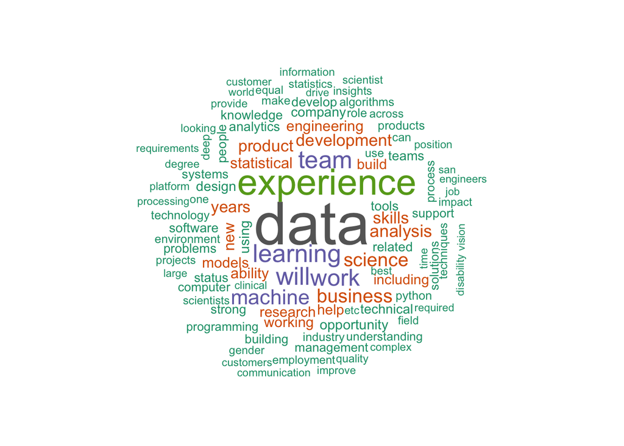

```r
library(tm)
library(wordcloud)

treat_corpus <- Corpus(VectorSource(df$description))

treat_corpus <- treat_corpus %>%
  tm_map(removePunctuation) %>%
  tm_map(removeNumbers) %>%
  tm_map(removeWords, stopwords("english"))

wordcloud(treat_corpus, max.words = 100, min.words = 5,
          random.order = F, colors = brewer.pal(8, "Dark2"))
```